# Reconciled against QuantLib — accuracy and throughput

- Show All Code
- Hide All Code
- View Source

A pricing library is only worth trusting if it agrees with a reference, and only worth using if it is fast. This notebook does both against [QuantLib](https://www.quantlib.org/): it reconciles Schenberg’s Black-Scholes price and delta to QuantLib’s `AnalyticEuropeanEngine` over thousands of random options, then compares throughput — QuantLib’s per-instrument loop versus Schenberg’s single vectorized Polars plan.

Conventions are matched on purpose: flat continuously-compounded rate, zero dividend, constant vol, Actual/365 day count, and **the same year fraction `T` fed to both engines** — so any difference is numerical, not a modelling artefact.

**Imports**

```python
import time
import numpy as np
import polars as pl
import matplotlib.pyplot as plt
import QuantLib as ql

from schenberg import var, log, sqrt, exp, normal_cdf, compile_polars, grad

plt.rcParams.update({"figure.dpi": 110, "axes.grid": True, "grid.alpha": 0.3})
rng = np.random.default_rng(20260607)
print("QuantLib", ql.__version__)
```

```
QuantLib 1.42.1
```

## 1. The two pricers

Schenberg’s price is one `Expr` compiled to a lazy Polars column; delta is that same `Expr` differentiated with JAX.

```python
S, K, r, sigma, T = (var(n) for n in ("S", "K", "r", "sigma", "T"))
d1 = (log(S / K) + (r + 0.5 * sigma**2) * T) / (sigma * sqrt(T))
d2 = d1 - sigma * sqrt(T)
call = S * normal_cdf(d1) - K * exp(-r * T) * normal_cdf(d2)

price_expr = compile_polars(call)


def schenberg_prices(df: pl.DataFrame) -> pl.Series:
    return df.lazy().select(price=price_expr).collect().get_column("price")


_DC = ql.Actual365Fixed()
_TODAY = ql.Date(6, 6, 2026)


def quantlib_price_delta(S_, K_, r_, sig_, days):
    ql.Settings.instance().evaluationDate = _TODAY
    spot = ql.SimpleQuote(S_)
    rate_ts = ql.YieldTermStructureHandle(ql.FlatForward(_TODAY, r_, _DC))
    div_ts = ql.YieldTermStructureHandle(ql.FlatForward(_TODAY, 0.0, _DC))
    vol_ts = ql.BlackVolTermStructureHandle(
        ql.BlackConstantVol(_TODAY, ql.NullCalendar(), sig_, _DC)
    )
    process = ql.BlackScholesMertonProcess(ql.QuoteHandle(spot), div_ts, rate_ts, vol_ts)
    payoff = ql.PlainVanillaPayoff(ql.Option.Call, K_)
    exercise = ql.EuropeanExercise(_TODAY + int(days))
    opt = ql.VanillaOption(payoff, exercise)
    opt.setPricingEngine(ql.AnalyticEuropeanEngine(process))
    return opt.NPV(), opt.delta()
```

## 2. Reconcile price and delta on a random book

```python
n = 4000
days = rng.integers(30, 730, n)
Tn = days / 365.0  # Actual/365 — the exact year fraction QuantLib will use
book = pl.DataFrame(
    {
        "S": rng.uniform(50, 150, n),
        "K": rng.uniform(50, 150, n),
        "r": rng.uniform(0.0, 0.12, n),
        "sigma": rng.uniform(0.05, 0.60, n),
        "T": Tn,
    }
)

sch_price = schenberg_prices(book).to_numpy()
sch_delta = np.asarray(grad(call, "S")({c: book[c].to_numpy() for c in book.columns}))

ql_price = np.empty(n)
ql_delta = np.empty(n)
for i in range(n):
    ql_price[i], ql_delta[i] = quantlib_price_delta(
        book["S"][i], book["K"][i], book["r"][i], book["sigma"][i], int(days[i])
    )

pl.DataFrame(
    {
        "quantity": ["price", "delta"],
        "max_abs_error": [
            float(np.max(np.abs(sch_price - ql_price))),
            float(np.max(np.abs(sch_delta - ql_delta))),
        ],
        "mean_abs_error": [
            float(np.mean(np.abs(sch_price - ql_price))),
            float(np.mean(np.abs(sch_delta - ql_delta))),
        ],
    }
)
```

shape: (2, 3)

| quantity str | max_abs_error f64 | mean_abs_error f64 |
| --- | --- | --- |
| "price" | 0.000018 | 0.000005 |
| "delta" | 0.000033 | 0.000001 |

The price error is dominated by Schenberg’s analytic normal-CDF approximation (Abramowitz-Stegun), which the JAX and Polars backends share — a few times `1e-5` on prices of order tens, and similar on delta.

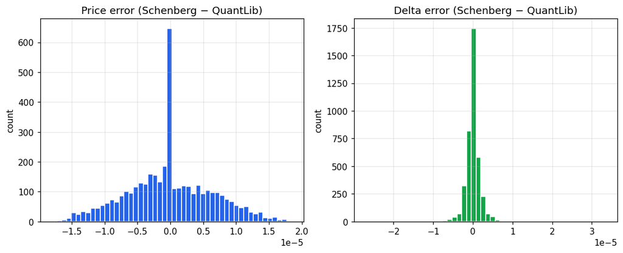

```python
fig, ax = plt.subplots(1, 2, figsize=(10, 4), constrained_layout=True)
ax[0].hist(sch_price - ql_price, bins=50, color="#2563eb", edgecolor="white")
ax[0].set_title("Price error (Schenberg − QuantLib)")
ax[1].hist(sch_delta - ql_delta, bins=50, color="#16a34a", edgecolor="white")
ax[1].set_title("Delta error (Schenberg − QuantLib)")
for a in ax:
    a.set_ylabel("count")
plt.show()
```

## 3. Throughput — one vectorized plan vs a per-option loop

```python
sizes = [1_000, 5_000, 20_000, 50_000]
sch_t, ql_t = [], []

for m in sizes:
    d = rng.integers(30, 730, m)
    df = pl.DataFrame(
        {
            "S": rng.uniform(50, 150, m), "K": rng.uniform(50, 150, m),
            "r": rng.uniform(0.0, 0.12, m), "sigma": rng.uniform(0.05, 0.60, m),
            "T": d / 365.0,
        }
    )
    t0 = time.perf_counter(); schenberg_prices(df); sch_t.append(time.perf_counter() - t0)

    Sv, Kv, rv, sv = (df[c].to_numpy() for c in ("S", "K", "r", "sigma"))
    t0 = time.perf_counter()
    for i in range(m):
        quantlib_price_delta(Sv[i], Kv[i], rv[i], sv[i], int(d[i]))
    ql_t.append(time.perf_counter() - t0)

speedup = [q / s for q, s in zip(ql_t, sch_t)]
pl.DataFrame(
    {
        "options": sizes,
        "schenberg_s": [round(x, 4) for x in sch_t],
        "quantlib_s": [round(x, 4) for x in ql_t],
        "speedup": [round(x, 1) for x in speedup],
    }
)
```

shape: (4, 4)

| options i64 | schenberg_s f64 | quantlib_s f64 | speedup f64 |
| --- | --- | --- | --- |
| 1000 | 0.0065 | 0.0613 | 9.5 |
| 5000 | 0.0068 | 0.2902 | 42.9 |
| 20000 | 0.0091 | 1.214 | 133.7 |
| 50000 | 0.0163 | 2.9483 | 181.3 |

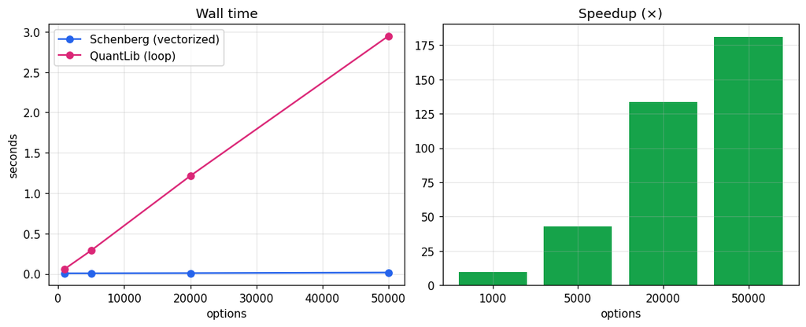

```python
fig, ax = plt.subplots(1, 2, figsize=(10, 4), constrained_layout=True)
ax[0].plot(sizes, sch_t, "o-", color="#2563eb", label="Schenberg (vectorized)")
ax[0].plot(sizes, ql_t, "o-", color="#db2777", label="QuantLib (loop)")
ax[0].set_title("Wall time"); ax[0].set_xlabel("options"); ax[0].set_ylabel("seconds"); ax[0].legend()
ax[1].bar([str(s) for s in sizes], speedup, color="#16a34a")
ax[1].set_title("Speedup (×)"); ax[1].set_xlabel("options")
plt.show()
```

Same model, matched conventions: Schenberg reconciles to QuantLib at the level of its analytic normal-CDF approximation, and prices a whole book in one lazy plan instead of an instrument-by-instrument loop. Accuracy *and* throughput — the two things a quant checks before trusting a pricer.